# R_Exam_03-20(1)

### 1. 산점도

##### **용도** : x축과 y축으로 이루어진 그래프에 두 변수의 값을 점으로 나타낸 그래프이다.

##### 삼점도를 이용하면 두 변수의 관계를 파악하는데 용이하다.

##### 또한, 산점도를 이용하면 값들이 얼마나 퍼져있는지(산포도)를 시각적으로 확인할 수 있다.

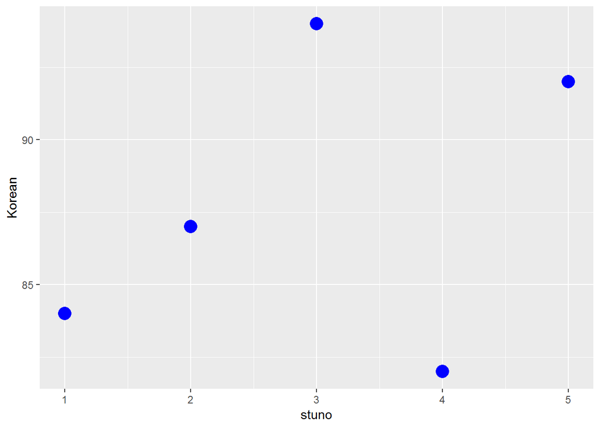

```r
library('ggplot2')

smdt = data.frame(stuno = 1:5,
                  Korean=sample(60:100, 5),
                  English=sample((5:10) * 10, 5),
                  Math=sample(50:100, 5))

ggplot() +
    geom_point(data=smdt,
              aes(x=stuno, y=Korean),
              color='blue', size = 5)
```

### 2. 꺾은선 그래프

##### **용도** : 꺾은선그래프(선도표)는 자료의 값을 점으로 표시하고 그 점들을 선으로 이어서 그린 그래프를 말한다.

##### 시계열 자료를 이용해서 시간의 흐름에 따라 값이 어떻게 변화하는지를 나타낼 때 많이 사용된다.

```r
library('dplyr')
```

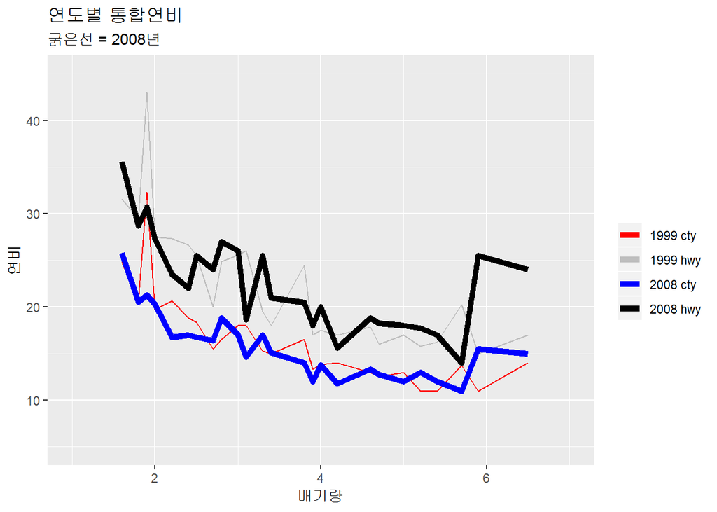

```r
mpg = as.data.frame(ggplot2::mpg)

d1 = mpg %>%
  filter(year == 1999) %>%
  group_by(year,displ) %>%
  summarise(m1 = mean(cty), m2 = mean(hwy))
d2 = mpg %>%
  filter(year == 2008) %>%
  group_by(year, displ) %>%
  summarise(m1 = mean(cty), m2 = mean(hwy))
b = bind_cols(d1, d2)

ggplot( b, aes(x=displ)) +
  geom_line(aes(y=m1, color='1999 cty')) +
  geom_line(aes(y=m2, color='1999 hwy')) +
  geom_line(aes(y=m11, color='2008 cty'), size=2) +
  geom_line(aes(y=m21, color='2008 hwy'), size=2) +
  scale_colour_manual("", breaks = c("1999 cty", "1999 hwy","2008 cty", "2008 hwy"),
                      values = c("red", "grey", "blue", "black")) +
  xlab("배기량") +
  xlim(1, 7) +
  scale_y_continuous("연비", limits = c(5, 45)) +
  labs(title = '연도별 통합연비', subtitle = '굵은선 = 2008년')  -> g4
g4
```

### 3. 막대 그래프

##### **용도** : 도수분포표를 막대모양으로 시각화한 것이 막대도표이다.

##### 다시 말하면 자료의 범주별 빈도를 요약해서 나타낸 그래프라고 할 수 있다.

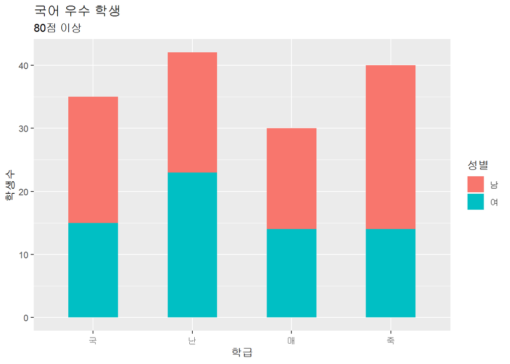

```r
load('data/data.rda')
data = dplyr::rename(data, stuno=학번, cls=반, gen=성별, math=수학, kor=국어, eng=영어, sci=과학, art=예체)
a = data  %>% group_by (cls, gen)%>% filter(kor >= 80)


ggplot(a, aes(cls)) +
  geom_bar(aes(fill=gen),
           width = 0.5) +
  theme(axis.text.x = element_text(angle=0,
                                   vjust=0.6)) +
  scale_fill_discrete(name = "성별") +
  xlab("학급") +
  ylab("학생수") +
  labs(title = '국어 우수 학생', subtitle = '80점 이상')
```

### 4. 히스토그램

##### **용도** : 히스토그램은 연속형 자료에 대한 도수분포표를 시각화한 그래프다.

##### 연속형 자료를 계급으로 나누어 계급별 도수를 막대로 나타낸다.

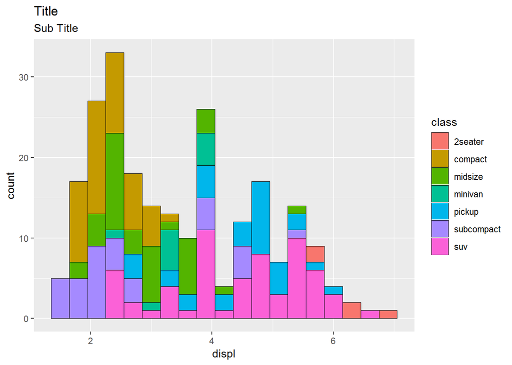

```r
ggplot(mpg, aes(displ)) +
  geom_histogram(aes(fill=class),
                 binwidth = .3,
                 col='black',
                 size=.1) +
  labs(title = 'Title', subtitle = 'Sub Title')
```

### 5. 분포,밀도그래프

##### **용도** : 분포,밀도그래프는 연속적인 확률변수의 분포를 연결된 선으로 연결하여 나타내며,

##### 어느 한 값(점) 에서의 높이는 그 값이 나올 확률이 어느정도 되는지, 데이터에서 얼마나 밀집하는지 나타낸다.

```r
try3 = data %>% group_by(cls) %>% filter(kor >= 95)
try3
```

```
## # A tibble: 34 x 8
## # Groups:   cls [4]
##    stuno cls   gen     kor   eng  math   sci   art
##    <int> <fct> <fct> <int> <int> <int> <int> <int>
##  1 10119 매    남       98    35    84    55    42
##  2 10213 난    남       97    50    26    82    49
##  3 10228 난    여       97    40    82    95    82
##  4 10230 난    여       98    35    73    34    77
##  5 10308 국    남       98    74    47    48    87
##  6 10314 국    남       96    52    80    58    35
##  7 10315 국    여       97    82    31    41    50
##  8 10334 국    여      100    48    88    91    41
##  9 10406 죽    남       96    95    74   100    51
## 10 10413 죽    남       99    49    97    86    87
## # ... with 24 more rows
```

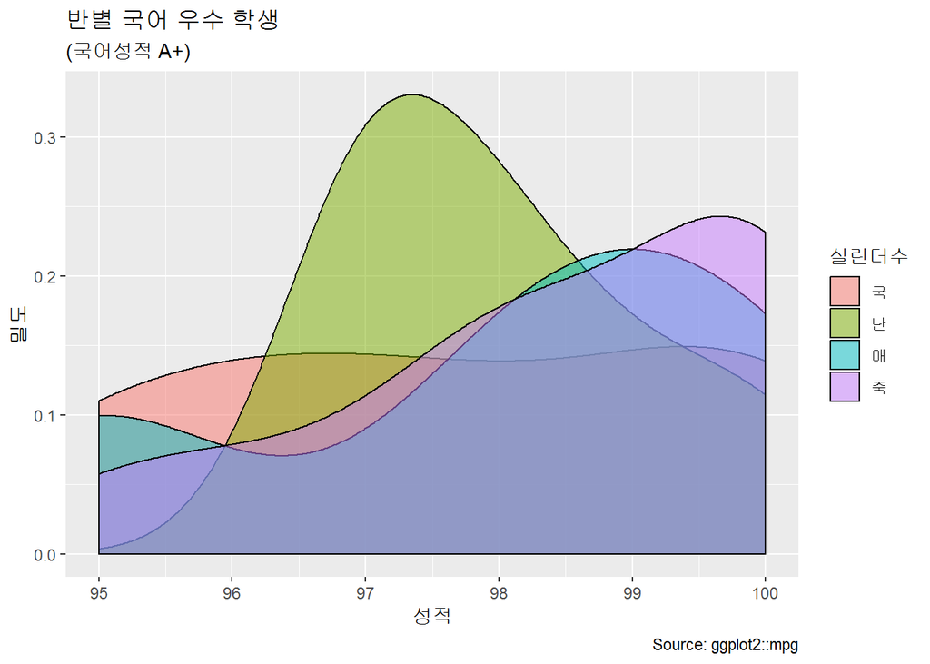

```r
ggplot(try3, aes(kor)) +
  geom_density(aes(fill=factor(cls)), alpha=0.5) +
  labs(title="반별 국어 우수 학생", subtitle = "(국어성적 A+)",
       caption="Source: ggplot2::mpg",
       x = "성적",
       y = "밀도",
       fill = "실린더수")
```